# Classification 1 Full Examples

Ryan Kelly

June 30, 2014

[Visit my website](http://rmdk.ca/) for more like this!

#### Data Sources:

Heavily borrowed from:

- Textbook: [Introduction to statistical learning](http://www-bcf.usc.edu/~gareth/ISL/)
- Textbook: [Elements of statistical learning](https://statistics.stanford.edu/~tibs/ElemStatLearn/)
- [Wikipedia](http://en.wikipedia.org/)

```r
require(knitr)
```

# Goals

Using the Boston data set, fit classification models in order to predict whether a given suburb has a crime rate above or below the median. Explore logistic regression, LDA, and KNN models using various sub- sets of the predictors. Describe your findings.

**Load the data**

```r
library(ISLR)
library(MASS)
library(caret)
attach(Boston)
kable(head(Boston))
```

| crim | zn | indus | chas | nox | rm | age | dis | rad | tax | ptratio | black | lstat | medv |
| --- | --- | --- | --- | --- | --- | --- | --- | --- | --- | --- | --- | --- | --- |
| 0.0063 | 18 | 2.31 | 0 | 0.538 | 6.575 | 65.2 | 4.090 | 1 | 296 | 15.3 | 396.9 | 4.98 | 24.0 |
| 0.0273 | 0 | 7.07 | 0 | 0.469 | 6.421 | 78.9 | 4.967 | 2 | 242 | 17.8 | 396.9 | 9.14 | 21.6 |
| 0.0273 | 0 | 7.07 | 0 | 0.469 | 7.185 | 61.1 | 4.967 | 2 | 242 | 17.8 | 392.8 | 4.03 | 34.7 |
| 0.0324 | 0 | 2.18 | 0 | 0.458 | 6.998 | 45.8 | 6.062 | 3 | 222 | 18.7 | 394.6 | 2.94 | 33.4 |
| 0.0690 | 0 | 2.18 | 0 | 0.458 | 7.147 | 54.2 | 6.062 | 3 | 222 | 18.7 | 396.9 | 5.33 | 36.2 |
| 0.0298 | 0 | 2.18 | 0 | 0.458 | 6.430 | 58.7 | 6.062 | 3 | 222 | 18.7 | 394.1 | 5.21 | 28.7 |

```r
# Create response variable
Boston$resp <- "No"
Boston$resp[crim > median(crim)] <- 'Yes'
Boston$resp <-factor(Boston$resp)
table(Boston$resp)
```

```
##
##  No Yes
## 253 253
```

```r
# Drop old crim variable
Boston <- Boston[-drop(1)]
```

The next thing we need to do is create training and testing data.

```r
inTrain <- createDataPartition(y = Boston$resp, p = 0.75, list = FALSE)

train <- Boston[inTrain,]
test <- Boston[-inTrain,]
```

```r
nzv <- nearZeroVar(train, saveMetrics = TRUE)
nzv
```

```
##         freqRatio percentUnique zeroVar   nzv
## zn         18.867        6.5789   FALSE FALSE
## indus       3.692       19.2105   FALSE FALSE
## chas       14.833        0.5263   FALSE FALSE
## nox         1.067       21.0526   FALSE FALSE
## rm          1.000       89.2105   FALSE FALSE
## age         8.000       73.4211   FALSE FALSE
## dis         1.250       83.1579   FALSE FALSE
## rad         1.055        2.3684   FALSE FALSE
## tax         3.200       16.5789   FALSE FALSE
## ptratio     3.400       11.5789   FALSE FALSE
## black      30.000       71.5789   FALSE FALSE
## lstat       1.000       91.3158   FALSE FALSE
## medv        1.667       52.8947   FALSE FALSE
## resp        1.000        0.5263   FALSE FALSE
```

```r
Cor <- cor(train[,-14])
Cor
```

```
##               zn    indus     chas      nox       rm      age      dis
## zn       1.00000 -0.52424 -0.03542 -0.51096  0.31290 -0.59214  0.67672
## indus   -0.52424  1.00000  0.03368  0.77584 -0.36871  0.66698 -0.71303
## chas    -0.03542  0.03368  1.00000  0.06477  0.09891  0.07968 -0.07433
## nox     -0.51096  0.77584  0.06477  1.00000 -0.31340  0.73443 -0.76083
## rm       0.31290 -0.36871  0.09891 -0.31340  1.00000 -0.23907  0.21622
## age     -0.59214  0.66698  0.07968  0.73443 -0.23907  1.00000 -0.75467
## dis      0.67672 -0.71303 -0.07433 -0.76083  0.21622 -0.75467  1.00000
## rad     -0.30260  0.59225 -0.08453  0.59039 -0.18011  0.45727 -0.48341
## tax     -0.30252  0.71298 -0.11089  0.65921 -0.25608  0.51642 -0.52994
## ptratio -0.39183  0.36206 -0.17284  0.17163 -0.30807  0.26215 -0.23127
## black    0.16278 -0.34511  0.03649 -0.35912  0.09519 -0.23070  0.27241
## lstat   -0.42880  0.63445 -0.01480  0.61647 -0.65071  0.62020 -0.52951
## medv     0.38466 -0.52092  0.12958 -0.48537  0.74945 -0.41887  0.31584
##              rad     tax ptratio    black   lstat    medv
## zn      -0.30260 -0.3025 -0.3918  0.16278 -0.4288  0.3847
## indus    0.59225  0.7130  0.3621 -0.34511  0.6345 -0.5209
## chas    -0.08453 -0.1109 -0.1728  0.03649 -0.0148  0.1296
## nox      0.59039  0.6592  0.1716 -0.35912  0.6165 -0.4854
## rm      -0.18011 -0.2561 -0.3081  0.09519 -0.6507  0.7495
## age      0.45727  0.5164  0.2622 -0.23070  0.6202 -0.4189
## dis     -0.48341 -0.5299 -0.2313  0.27241 -0.5295  0.3158
## rad      1.00000  0.9151  0.4737 -0.43134  0.5324 -0.4556
## tax      0.91512  1.0000  0.4628 -0.43459  0.5839 -0.5355
## ptratio  0.47367  0.4628  1.0000 -0.16745  0.3825 -0.5273
## black   -0.43134 -0.4346 -0.1675  1.00000 -0.3207  0.3281
## lstat    0.53236  0.5839  0.3825 -0.32068  1.0000 -0.7456
## medv    -0.45562 -0.5355 -0.5273  0.32809 -0.7456  1.0000
```

```r
highCor <- findCorrelation(Cor, cutoff = 0.75)
highCor
```

```
## [1] 2 4 9 6
```

```r
train_cor <- train[,-drop(c(2,9))]
test_cor <- test[,-drop(c(2,9))]
```

Now let’s try a few models…

## KNN

```r
knnGrid <- expand.grid(.k=c(2))
# Use k = 2, since we expect 2 classes
KNN <- train(x=train_cor[,-12], method='knn',
             y=train_cor$resp,
             preProcess=c('center', 'scale'),
             tuneGrid = knnGrid)
KNN
```

```
## k-Nearest Neighbors
##
## 380 samples
##  11 predictors
##   2 classes: 'No', 'Yes'
##
## Pre-processing: centered, scaled
## Resampling: Bootstrapped (25 reps)
##
## Summary of sample sizes: 380, 380, 380, 380, 380, 380, ...
##
## Resampling results
##
##   Accuracy  Kappa  Accuracy SD  Kappa SD
##   0.9       0.7    0.02         0.04
##
## Tuning parameter 'k' was held constant at a value of 2
##
```

```r
confusionMatrix(predict(KNN, test_cor[,-12]), test_cor$resp)
```

```
## Confusion Matrix and Statistics
##
##           Reference
## Prediction No Yes
##        No  53  11
##        Yes 10  52
##
##                Accuracy : 0.833
##                  95% CI : (0.757, 0.894)
##     No Information Rate : 0.5
##     P-Value [Acc > NIR] : 6.27e-15
##
##                   Kappa : 0.667
##  Mcnemar's Test P-Value : 1
##
##             Sensitivity : 0.841
##             Specificity : 0.825
##          Pos Pred Value : 0.828
##          Neg Pred Value : 0.839
##              Prevalence : 0.500
##          Detection Rate : 0.421
##    Detection Prevalence : 0.508
##       Balanced Accuracy : 0.833
##
##        'Positive' Class : No
##
```

This gives us pretty good results, however, let’s try using principal component analysis instead of removing correlated variables.

```r
KNN <- train(x=train[,-14], method='knn',
             y=train$resp,
             preProcess=c('center', 'scale', 'pca'),
             tuneGrid = knnGrid)
KNN
```

```
## k-Nearest Neighbors
##
## 380 samples
##  13 predictors
##   2 classes: 'No', 'Yes'
##
## Pre-processing: centered, scaled, principal component signal extraction
## Resampling: Bootstrapped (25 reps)
##
## Summary of sample sizes: 380, 380, 380, 380, 380, 380, ...
##
## Resampling results
##
##   Accuracy  Kappa  Accuracy SD  Kappa SD
##   0.9       0.7    0.03         0.07
##
## Tuning parameter 'k' was held constant at a value of 2
##
```

```r
confusionMatrix(predict(KNN, test[,-14]), test$resp)
```

```
## Confusion Matrix and Statistics
##
##           Reference
## Prediction No Yes
##        No  55   7
##        Yes  8  56
##
##                Accuracy : 0.881
##                  95% CI : (0.811, 0.932)
##     No Information Rate : 0.5
##     P-Value [Acc > NIR] : <2e-16
##
##                   Kappa : 0.762
##  Mcnemar's Test P-Value : 1
##
##             Sensitivity : 0.873
##             Specificity : 0.889
##          Pos Pred Value : 0.887
##          Neg Pred Value : 0.875
##              Prevalence : 0.500
##          Detection Rate : 0.437
##    Detection Prevalence : 0.492
##       Balanced Accuracy : 0.881
##
##        'Positive' Class : No
##
```

## Logistic Regression

```r
logit <- train(resp~., data=train,
               method='glm', family=binomial(link='logit'),
               preProcess=c('scale', 'center'))
summary(logit)
```

```
##
## Call:
## NULL
##
## Deviance Residuals:
##     Min       1Q   Median       3Q      Max
## -2.1648  -0.1199  -0.0001   0.0006   2.4565
##
## Coefficients:
##             Estimate Std. Error z value Pr(>|z|)
## (Intercept)    3.196      0.858    3.72   0.0002 ***
## zn            -2.257      1.108   -2.04   0.0417 *
## indus         -0.585      0.377   -1.55   0.1213
## chas           0.196      0.213    0.92   0.3567
## nox            6.603      1.146    5.76  8.4e-09 ***
## rm            -0.529      0.581   -0.91   0.3629
## age            0.591      0.410    1.44   0.1500
## dis            1.705      0.581    2.93   0.0034 **
## rad            6.897      1.686    4.09  4.3e-05 ***
## tax           -0.899      0.549   -1.64   0.1011
## ptratio        0.954      0.319    2.99   0.0028 **
## black         -0.849      0.527   -1.61   0.1074
## lstat          0.402      0.418    0.96   0.3356
## medv           1.911      0.743    2.57   0.0101 *
## ---
## Signif. codes:  0 '***' 0.001 '**' 0.01 '*' 0.05 '.' 0.1 ' ' 1
##
## (Dispersion parameter for binomial family taken to be 1)
##
##     Null deviance: 526.79  on 379  degrees of freedom
## Residual deviance: 154.74  on 366  degrees of freedom
## AIC: 182.7
##
## Number of Fisher Scoring iterations: 9
```

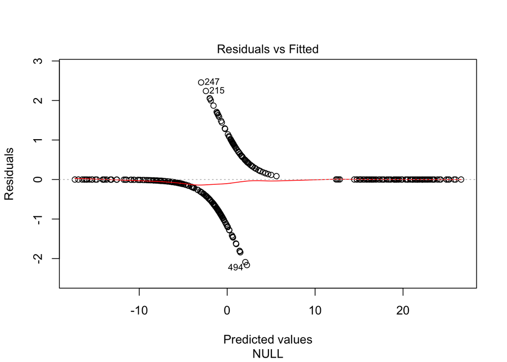

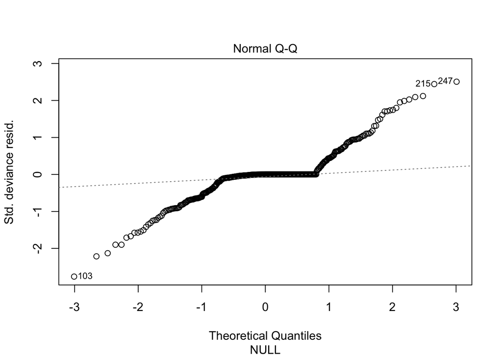

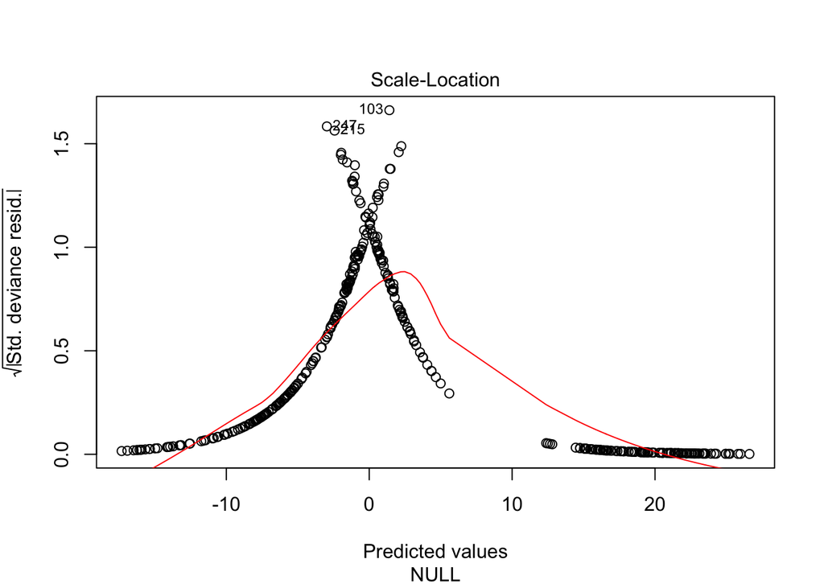

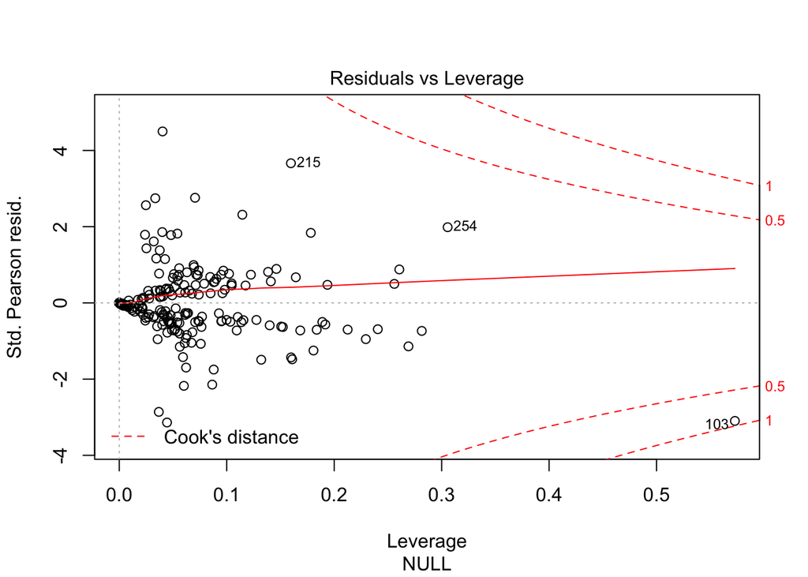

```r
plot(logit$finalModel,)
```

```r
confusionMatrix(predict(logit, test[,-14]), test$resp)
```

```
## Confusion Matrix and Statistics
##
##           Reference
## Prediction No Yes
##        No  58   5
##        Yes  5  58
##
##                Accuracy : 0.921
##                  95% CI : (0.859, 0.961)
##     No Information Rate : 0.5
##     P-Value [Acc > NIR] : <2e-16
##
##                   Kappa : 0.841
##  Mcnemar's Test P-Value : 1
##
##             Sensitivity : 0.921
##             Specificity : 0.921
##          Pos Pred Value : 0.921
##          Neg Pred Value : 0.921
##              Prevalence : 0.500
##          Detection Rate : 0.460
##    Detection Prevalence : 0.500
##       Balanced Accuracy : 0.921
##
##        'Positive' Class : No
##
```

Most of these variables are actually not significant in the model, we might as well remove the non-significant ones.

```r
library(car)

logit <- train(resp ~ rad + nox,
               data=train,
               method='glm', family=binomial(link='logit'),
               preProcess=c('scale', 'center'))
summary(logit)
```

```
##
## Call:
## NULL
##
## Deviance Residuals:
##     Min       1Q   Median       3Q      Max
## -1.9986  -0.3258  -0.0221   0.0050   2.1363
##
## Coefficients:
##             Estimate Std. Error z value Pr(>|z|)
## (Intercept)    3.047      0.610    4.99  5.9e-07 ***
## rad            5.282      1.062    4.97  6.5e-07 ***
## nox            3.396      0.454    7.47  7.9e-14 ***
## ---
## Signif. codes:  0 '***' 0.001 '**' 0.01 '*' 0.05 '.' 0.1 ' ' 1
##
## (Dispersion parameter for binomial family taken to be 1)
##
##     Null deviance: 526.79  on 379  degrees of freedom
## Residual deviance: 193.78  on 377  degrees of freedom
## AIC: 199.8
##
## Number of Fisher Scoring iterations: 8
```

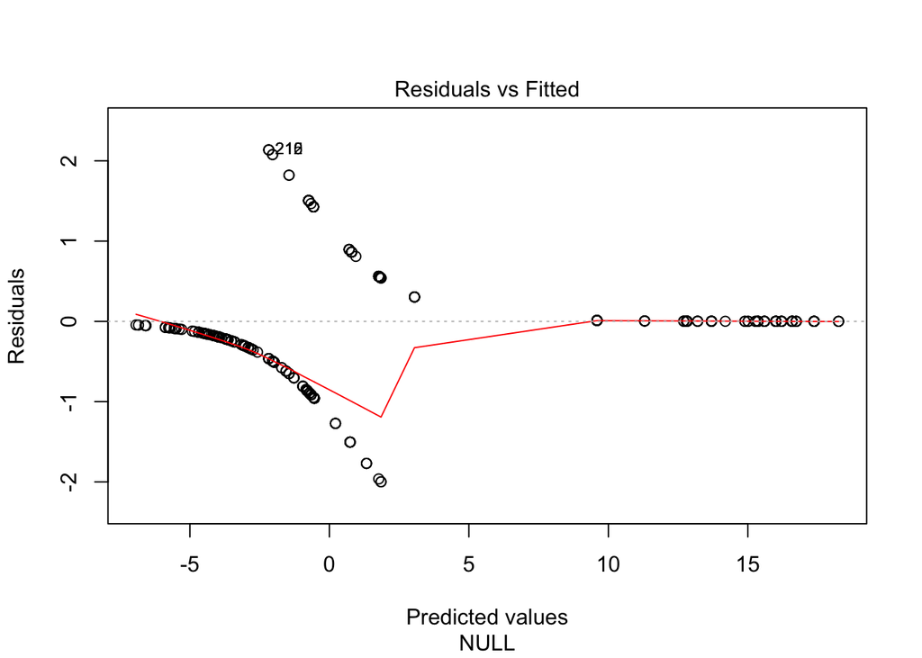

```r
plot(logit$finalModel, which=1)
```

```r
vif(logit$finalModel)
```

```
##   rad   nox
## 1.147 1.147
```

```r
confusionMatrix(predict(logit, test[,-14]), test$resp)
```

```
## Confusion Matrix and Statistics
##
##           Reference
## Prediction No Yes
##        No  57  12
##        Yes  6  51
##
##                Accuracy : 0.857
##                  95% CI : (0.784, 0.913)
##     No Information Rate : 0.5
##     P-Value [Acc > NIR] : <2e-16
##
##                   Kappa : 0.714
##  Mcnemar's Test P-Value : 0.239
##
##             Sensitivity : 0.905
##             Specificity : 0.810
##          Pos Pred Value : 0.826
##          Neg Pred Value : 0.895
##              Prevalence : 0.500
##          Detection Rate : 0.452
##    Detection Prevalence : 0.548
##       Balanced Accuracy : 0.857
##
##        'Positive' Class : No
##
```

## LDA

```r
LDA <- train(resp~., data=train_cor,
             method='lda',
             preProcess=c('scale', 'center'))
LDA
```

```
## Linear Discriminant Analysis
##
## 380 samples
##  11 predictors
##   2 classes: 'No', 'Yes'
##
## Pre-processing: scaled, centered
## Resampling: Bootstrapped (25 reps)
##
## Summary of sample sizes: 380, 380, 380, 380, 380, 380, ...
##
## Resampling results
##
##   Accuracy  Kappa  Accuracy SD  Kappa SD
##   0.8       0.7    0.03         0.06
##
##
```

```r
confusionMatrix(test_cor$resp, predict(LDA, test_cor[,-12]))
```

```
## Confusion Matrix and Statistics
##
##           Reference
## Prediction No Yes
##        No  61   2
##        Yes 15  48
##
##                Accuracy : 0.865
##                  95% CI : (0.793, 0.919)
##     No Information Rate : 0.603
##     P-Value [Acc > NIR] : 1.05e-10
##
##                   Kappa : 0.73
##  Mcnemar's Test P-Value : 0.00361
##
##             Sensitivity : 0.803
##             Specificity : 0.960
##          Pos Pred Value : 0.968
##          Neg Pred Value : 0.762
##              Prevalence : 0.603
##          Detection Rate : 0.484
##    Detection Prevalence : 0.500
##       Balanced Accuracy : 0.881
##
##        'Positive' Class : No
##
```

## QDA

```r
QDA <- train(resp~., data=train_cor,
             method='qda',
             preProcess=c('scale', 'center'))
QDA
```

```
## Quadratic Discriminant Analysis
##
## 380 samples
##  11 predictors
##   2 classes: 'No', 'Yes'
##
## Pre-processing: scaled, centered
## Resampling: Bootstrapped (25 reps)
##
## Summary of sample sizes: 380, 380, 380, 380, 380, 380, ...
##
## Resampling results
##
##   Accuracy  Kappa  Accuracy SD  Kappa SD
##   0.9       0.7    0.03         0.05
##
##
```

```r
confusionMatrix(test_cor$resp, predict(LDA, test_cor[,-12]))
```

```
## Confusion Matrix and Statistics
##
##           Reference
## Prediction No Yes
##        No  61   2
##        Yes 15  48
##
##                Accuracy : 0.865
##                  95% CI : (0.793, 0.919)
##     No Information Rate : 0.603
##     P-Value [Acc > NIR] : 1.05e-10
##
##                   Kappa : 0.73
##  Mcnemar's Test P-Value : 0.00361
##
##             Sensitivity : 0.803
##             Specificity : 0.960
##          Pos Pred Value : 0.968
##          Neg Pred Value : 0.762
##              Prevalence : 0.603
##          Detection Rate : 0.484
##    Detection Prevalence : 0.500
##       Balanced Accuracy : 0.881
##
##        'Positive' Class : No
##
```

## Random Forests

```r
library(doMC)
registerDoMC(6)

fun <- train(y=train$resp, x=train[,-14])
fun
```

```
## Random Forest
##
## 380 samples
##  13 predictors
##   2 classes: 'No', 'Yes'
##
## No pre-processing
## Resampling: Bootstrapped (25 reps)
##
## Summary of sample sizes: 380, 380, 380, 380, 380, 380, ...
##
## Resampling results across tuning parameters:
##
##   mtry  Accuracy  Kappa  Accuracy SD  Kappa SD
##   2     1         0.9    0.02         0.04
##   7     1         0.9    0.02         0.04
##   10    1         0.9    0.02         0.04
##
## Accuracy was used to select the optimal model using  the largest value.
## The final value used for the model was mtry = 7.
```

```r
confusionMatrix(test$resp, predict(fun, test[,-14]))
```

```
## Confusion Matrix and Statistics
##
##           Reference
## Prediction No Yes
##        No  60   3
##        Yes  5  58
##
##                Accuracy : 0.937
##                  95% CI : (0.879, 0.972)
##     No Information Rate : 0.516
##     P-Value [Acc > NIR] : <2e-16
##
##                   Kappa : 0.873
##  Mcnemar's Test P-Value : 0.724
##
##             Sensitivity : 0.923
##             Specificity : 0.951
##          Pos Pred Value : 0.952
##          Neg Pred Value : 0.921
##              Prevalence : 0.516
##          Detection Rate : 0.476
##    Detection Prevalence : 0.500
##       Balanced Accuracy : 0.937
##
##        'Positive' Class : No
##
```

## Moving forward with logistic regression

One of the benefits of logistic regression is that we can begin to understand which variables are more important to the model, therefore we gain insight into the behavior of the real word phenomena. Well this isn’t the best model, we will use this simpler model as an example to explain the results.

### Interpreting the odds ratios

```r
# Getting odds ratio and 95% conf intervals
exp(cbind(OR = coef(logit$finalModel), confint(logit$finalModel)))
```

```
##                 OR  2.5 %  97.5 %
## (Intercept)  21.06  6.704   74.40
## rad         196.74 27.074 1776.74
## nox          29.83 13.140   79.05
```

```r
attach(Boston)
```

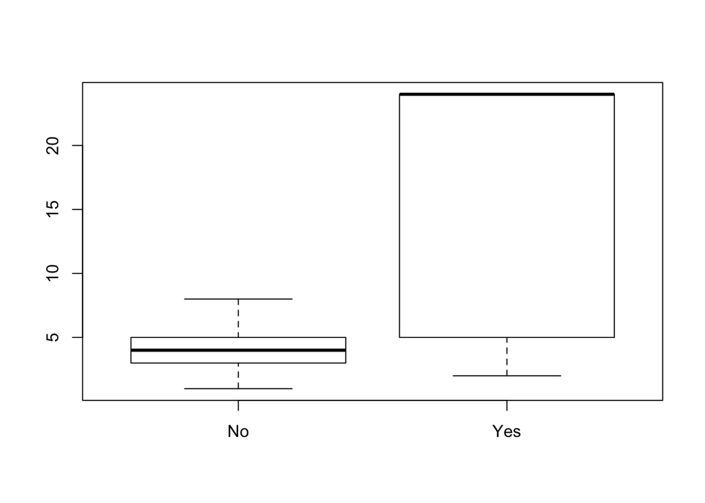

```r
plot(Boston$resp, rad)
```